# Generating multiple ggplot plots using purrr

Edgar Zamora

2020-02-20

For a quick solution to this question I would encourage you to check out my answer on [stackoverflow](https://stackoverflow.com/questions/57298510/how-to-generate-multiple-similar-ggplots-together/57314675#57314675).

First things first, lets load all the necessary packages.

```r
library(tidyverse)
library(patchwork)
library(blogdown)
library(knitr)
```

# The problem

```r
plot1 <- mpg %>%
  count(cyl, drv) %>%
  ggplot(aes(cyl, n, fill = drv)) +
  geom_col(position = position_dodge()) +
  labs(title = "",
       x = "Number of Cylinders",
       y = "Count") +
  scale_fill_manual(name = "Drive Train",
                    values = c("grey75", "steelblue", "#13F09F"),
                    labels = c("4wd", "front-wheel drive", "rear wheel drive")) +
  theme(
    panel.background = element_blank(),
    panel.grid.major = element_line(colour = "grey80", size = .15),
    axis.ticks = element_blank(),
    legend.position = "bottom"
  )
```

[figure not shown]

```r
plot2 <- mpg %>%
  count(class, drv) %>%
  ggplot(aes(class, n, fill = drv)) +
  geom_col(position = position_dodge()) +
  labs(title = "",
       x = "Vehicle Class",
       y = "Count") +
  scale_fill_manual(name = "Drive Train",
                    values = c("grey75", "steelblue", "#13F09F"),
                    labels = c("4wd", "front-wheel drive", "rear wheel drive")) +
  theme(
    panel.background = element_blank(),
    panel.grid.major = element_line(colour = "grey80", size = .15),
    axis.ticks = element_blank(),
    legend.position = "bottom"
  )
```

## Why a function?

There are a myriad of reasons for turning repetitive graphics into a function, but here are mine:

1. I am lazy and do not want to spend time copying and pasting code from one section to another in a single document. Also I would rather spend more time with my CATS!!!
2. Having a single function will allow you to debug issues quicker. Instead of having to look through multiple different code snippets, you can focus on one.
3. Similar to solving issues quicker, one can also increase their workflow and productively. Gone are those days were graphics are a large part of document.
4. When creating functions for graphics you can spend less time on the building of the graphic and more time on customizing it to fit your needs.

For additoinal reason for writing a function over copying and pasting, check out [Chapter 19](https://r4ds.had.co.nz/functions.html) in R for Data Science by Grolemund and Wickham (2017).

# Lets put the fun in (fun)ction

If you take a look at the code for both graphics from above, you can spot three differences:

1. The first variable in the `count()` function is different, in that one variable is “cyl” and the other is “class”.
2. The variable in the ggplot aesthetic also varies in the same way that the `count()` function did.
3. The x-axis labels are different in that one references the “Number of Cylinders” while the other references “Vehicle Class”.

Knowing that these are the only differences among both graphics, we can instruct the function to change according to those arguments. **Note** for this to work you should have the latest `rlang’ version installed.

```r
repetitive_ggplot <- function(variable){
  mpg %>%
    count({{variable}}, drv) %>%
    ggplot(aes({{variable}}, n, fill = drv)) +
    geom_col(position = position_dodge()) +
    labs(title = "",
         x = "",
         y = "Count") +
    scale_fill_manual(name = "Drive Train",
                      values = c("grey75", "steelblue", "#13F09F"),
                      labels = c("4wd", "front-wheel drive", "rear wheel drive")) +
    theme(
      panel.background = element_blank(),
      panel.grid.major = element_line(colour = "grey80", size = .15),
      axis.ticks = element_blank(),
      legend.position = "bottom"
      )
}
```

Having created our function, we can than feed our variables through the arguments of the function to produce our plots as seen below

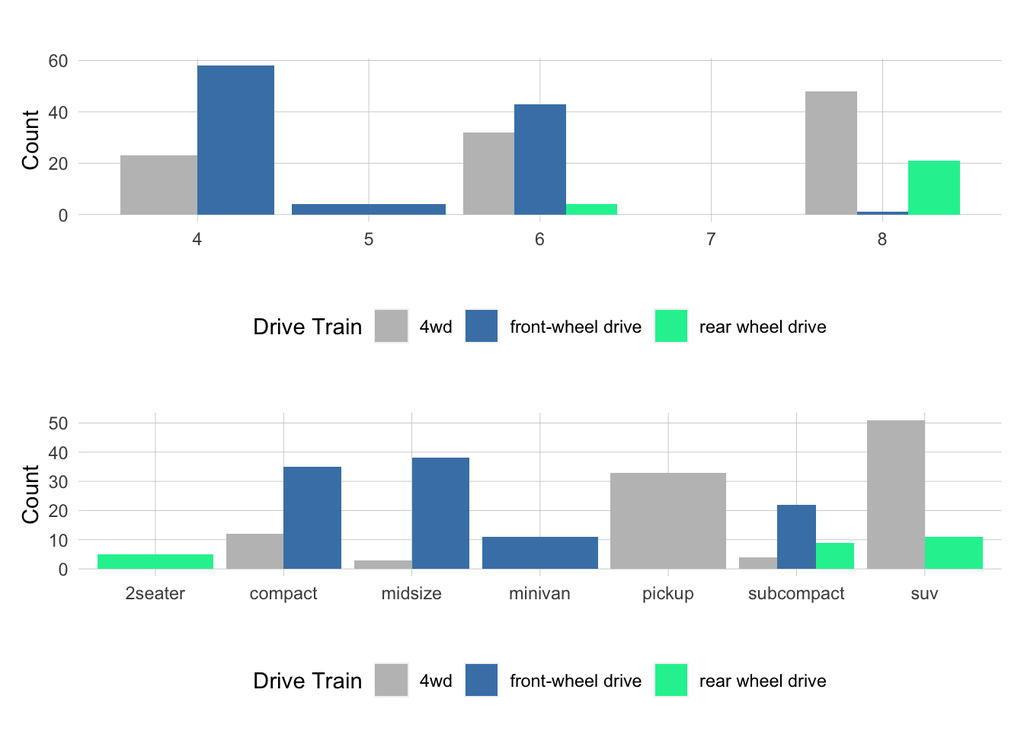

```r
fun_plot1 <- repetitive_ggplot(cyl)

fun_plot2 <- repetitive_ggplot(class)

fun_plot1/fun_plot2 #patchwork to create stacked plots
```

```r
fun_plot1 <- repetitive_ggplot(cyl) +
  labs(x = "Number of Cylinders")

fun_plot2 <- repetitive_ggplot(class) +
  labs(x = "Vehicle Class")
```

Doing this only overrides the specific argument within the command. Inside we define the y-axis title as “Count” which if you printed the plot would still be preserved. The only overwritten aspects are those defined within, which in this case was the x-axis label.

# Making it Purrr

As indicated by the title of this post, we are also going to use the `purrr` package to take this function a step further by automating the need run each new plot independently as we did above. To do so we will use the `map` functions from the `purrr` package, specifically we will be using `map`.

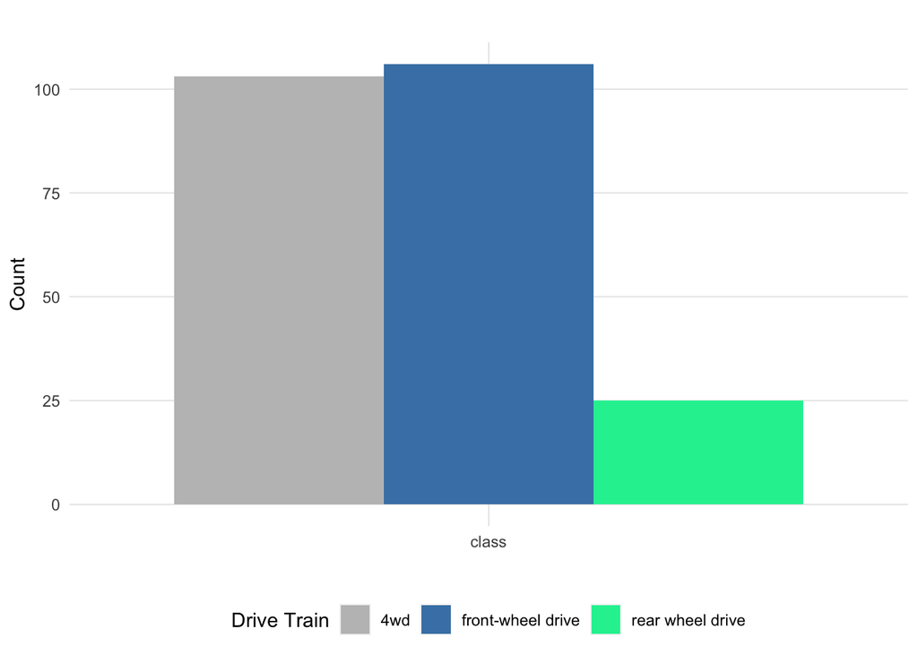

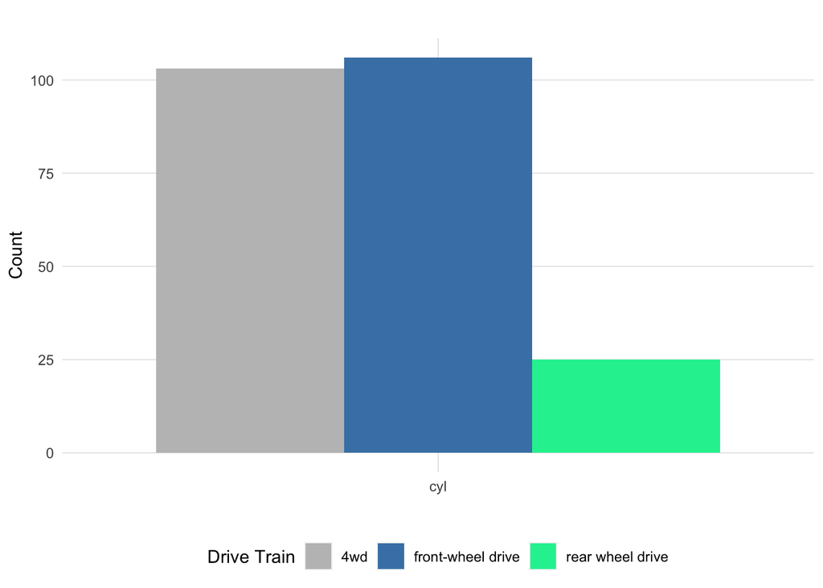

```r
variables <- mpg %>%
  select(class, cyl) %>%
  names()

xxx <- function(x){
  repetitive_ggplot({{x}})
}

map(variables, xxx)
```

For more specific about the `purrr` package and its various functions I encourage you to check out the `purrr` documentation [page](https://purrr.tidyverse.org) or the R [cheat sheets](https://rstudio.com/resources/cheatsheets/).

# Conclusion

By following this guide you can start to turn some of your repetive code into code that is cleaner, quicker and more efficient. In no way is this the end, rather it is the start to increasing productivety in ones workflow. There are few things that you should remember before embarking in creating a function for your multiple plots. It is important to rember that there needs to be some variation within each visualization but not so much that you can not create a function. There is no magic number I can prescribe but once you starting working you will notice trends.